# Bayesball Analysis

Matt Lukac

### Data exploration

We have collected some data on the 2012 Major League Baseball (MLB) season. Here is a look at the data for the first 6 players.

| Player | PriPos | Hits | AtBats | PlayerNumber | PriPosNumber |
| --- | --- | --- | --- | --- | --- |
| Fernando Abad | Pitcher | 1 | 7 | 1 | 1 |
| Bobby Abreu | Left Field | 53 | 219 | 2 | 7 |
| Tony Abreu | 2nd Base | 18 | 70 | 3 | 4 |
| Dustin Ackley | 2nd Base | 137 | 607 | 4 | 4 |
| Matt Adams | 1st Base | 21 | 86 | 5 | 3 |
| Nathan Adcock | Pitcher | 0 | 1 | 6 | 1 |

As we can see, we have the following variables:

- `Player`: the player name
- `PriPos`: the primary position of the player
- `Hits`: the total number of hits in 2012
- `AtBats`: the total number of at bats in 2012
- `PlayerNumber`: the rank in the list of players, i.e. the row number
- `PriPosNumber`: a numerical value associated to player’s primary position

For the uninitiated, there are 9 positions in baseball: pitcher, catcher, 1st baseman, 2nd baseman, shortstop, 3rd baseman, shortstop, left, center, and right fielders. I have listed the positions according the their official ordering, see the following diagram.

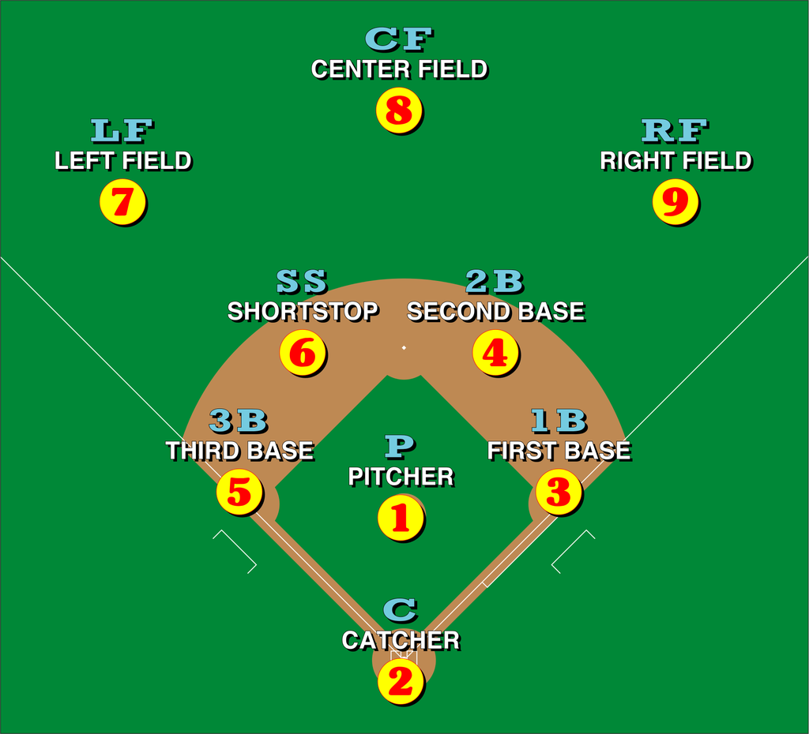

By Michael J - Own work, CC BY-SA 4.0, https://commons.wikimedia.org/w/index.php?curid=40095322

A player’s reported *batting average* is the observed proportion of at bats that result in a hit. We would like to make inference on batting averages, both at the player level and the position level. In particular, we would like to answer the following questions:

1. **What is the typical batting average and range of variation for players in each position?**
2. **How many right fielders have a higher lower batting average than the 95th percentile of pitcher’s batting averages?**
3. **What are the theoretical batting averages, with reported uncertainty, for both Prince Fielder and Thomas Field?**

Before tackling these questions, we should explore the data a bit more. We have a total of 948 players, with various amounts grouped by position. Observe the plots below. On the left is a barplot showing how the players are distributed about the primary positions. Note we have more pitchers in our dataset than any other position, making up 324 of the 948 players. Of the non-pitchers, the right fielders make up the least observations, with only 60. The most non-pitcher observations is a tie between catchers and left fielders with 103 players.

Below on the right we can see the empirical batting averages, grouped by position. The transparency measures how many total at bats each player had; the opacity of the point scales with the number of at bats. We can see that for all non-pitcher positions the players have plenty of at bats with a tight spread around the center. Pitchers, on the other hand, generally have quite translucent points with a rather large spread. The seemingly opaque points for pitchers are not acutally solid, there are just many tranparent points on top of each other; there were 158 pitchers that had 0 hits in 2012.

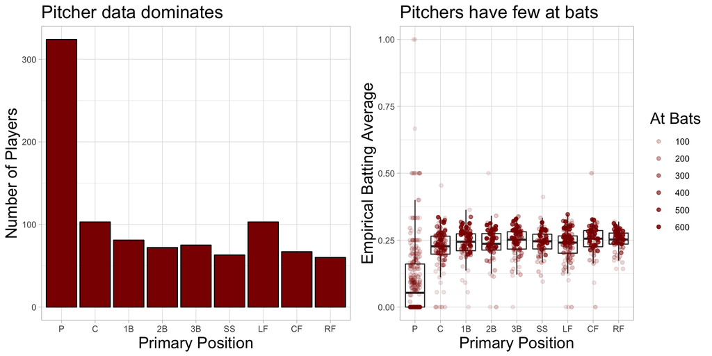

### The Model

To model the data, we first suppose each player’s (empirical) batting average is an estimate of some true batting average. More precisely, for $i=1,2,\ldots, 948$ we assume the $i$th player has some intrinsic probability $\theta_i$ of getting a hit. It then follows that the (random) number of hits $K_i$ player $i$ will get after $n_i$ at bats is binomially distributed with success $\theta_i$.

Furthermore we assume the batting average for players in each position follow the same distribution. The beta distribution is a natural choice to put on probabilities. Since we are concerned with typical batting averages and their spread we will parameterize the beta distribution using the mean $\mu$ and concentration $\kappa$, which measure center and spread, respectively. Letting $p_i=1,2,\ldots,9$ index the primary position of player $i$, our model can be written as
$$K_i \sim \operatorname{Binom}(n_i, \theta_{p_i})
\quad \text{and} \quad
\theta_{p_i} \sim \operatorname{Beta}(\mu_p\kappa_p, (1-\mu_p)\kappa_p)$$
Our goal is to use the data along with this model to obtain samples from the posterior distributions for the 948 $\theta_{p_i}$ parameters, and the 18 total hyperparameters $\mu_p$ and $\kappa_p$. The sampling will be done via Markov Chain Monte Carlo (MCMC) using [Stan](https://mc-stan.org/). Once we obtain the samples, we will use posterior estimates to answer the above 3 questions.

### Posterior sampling

Speaking of sampling, we will use 4 Markov chains each with 2000 iterations. The first 1000 iterations will be the warmup phase, so in the end we will have 4000 total samples from each posterior distribution. Our choices of priors are $\mu_p \sim \operatorname{Beta}(1,1)$ and $\kappa_p \sim \operatorname{Gamma}(0.1, 0.1)$.

We could look at trace plots to determine if our chains mixed, but because of the large number of parameters it is wise to just look at how $\hat R$ is distributed. $\hat R$ measures mixing of chains by comparing the between-chain and whithin-chain estimates for our model parameters. Thus the closer $\hat R$ is to 1, the better the mixing. The `rstan` documentation [suggests](https://rdrr.io/cran/rstan/man/Rhat.html) the chains have mixed well whenever $0.95 < \hat R < 1.05$. Below is a summary of all $\hat R$ values for all 966 parameters. Observe that all $\hat R$’s are well within the acceptable range, suggesting our chains have mixed enough for us to trust the posterior samples.

| Min | 1st Quartile | Median | Mean | 3rd Quartile | Max |
| --- | --- | --- | --- | --- | --- |
| 0.9990 | 0.9996 | 0.9998 | 1.0000 | 1.0002 | 1.0156 |

This information is further visualized with the following histogram. Note the bars are all yellow (so $\hat R < 1.05$) and very few of them exceed 1.0015697.

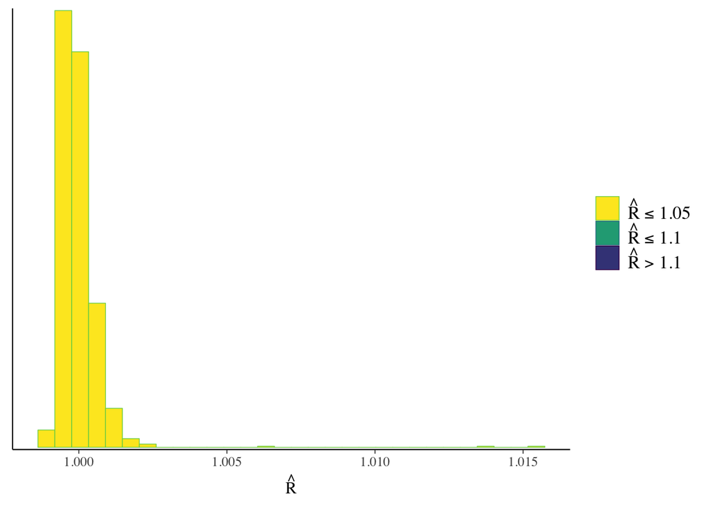

To get a sense of the posterior distributions, we’ll take a look at the posterior median, 80% credible region, and 95% credible region for $\mu$ and $\kappa$. See the below plot, recalling the ordering on positions. Unsurprisingly, batting averages for pitchers have a lower mean compared to all other positions. The posterior mean for pitchers is 0.129 whereas the other positions range from 0.239 to 0.259.

All positions typically have a high concentration, meaning the batting averages for players within a position tend to not deviate too much from one another. Pitchers, on the other hand, have the lowest concentration. This was intuitively evident from our empirical batting averages plot above, so it’s good that Stan has picked up on this. We must have a good model!

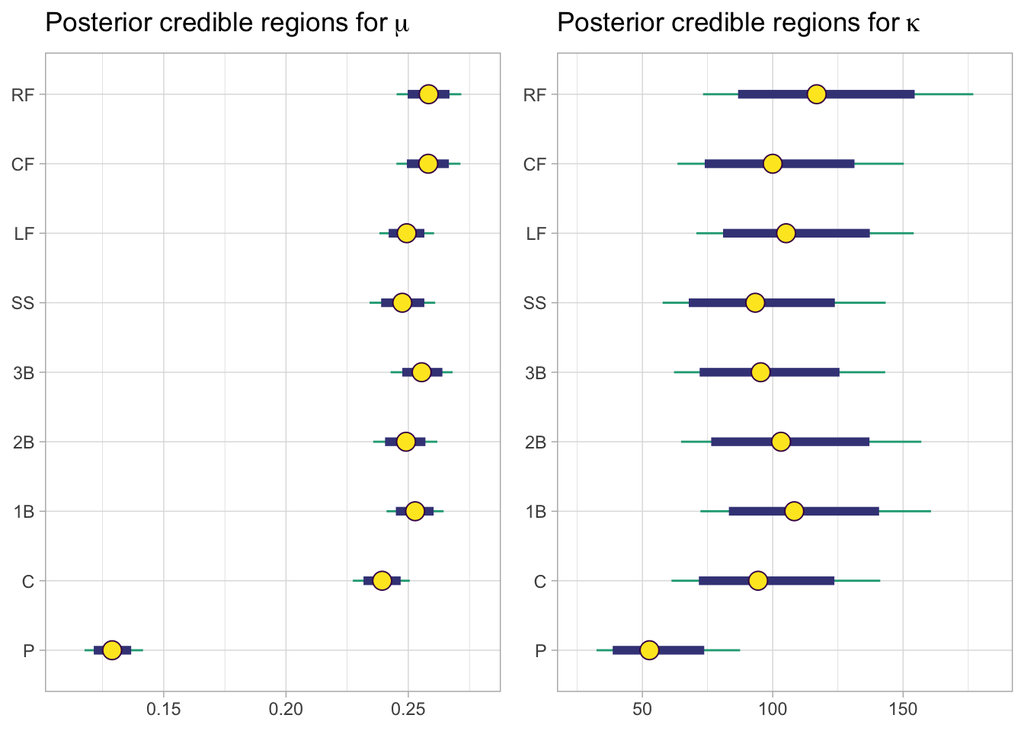

### Inference

We’re now in a position to answer the previous three questions. As a reminder, they were

1. What is the typical batting average and range of variation for players in each position?
2. How many right fielders have a higher lower batting average than the 95th percentile of pitcher’s batting averages?
3. What are the theoretical batting averages, with reported uncertainty, for both Prince Fielder and Thomas Field?

#### Question 1

We have already begun to answer this question in the previous section, where we noted pitchers tend to have a lower mean batting average with a higher spread, as compared to other positions. To get a sense of how our inferred distributions of batting averages vary by position, consider the following plot. Using the posterior means of $\mu$ and $\kappa$ we have plotted all 9 inferred batting average distributions. It might be easier to see here that pitchers tend to have much lower batting averages than other positions. Slightly less obvious is that the pitcher’s distribution is wider than the others, which was indicated earlier when we saw pitchers had a lower concentration.

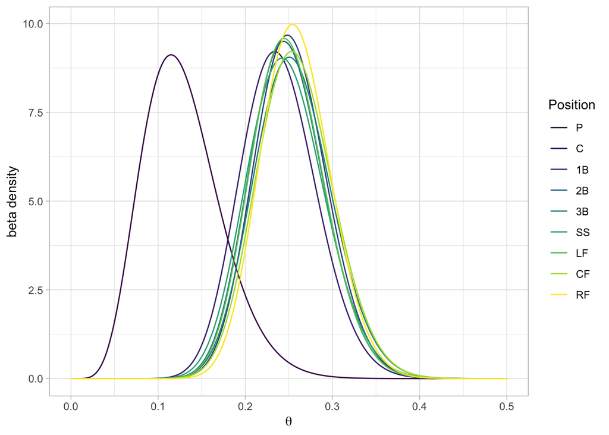

The plot above is a good visual, but to cover all our bases we will present the estimated batting average means and standard deviations in the following table, of course grouped by position.

Batting Average Estimates

|  | P | C | 1B | 2B | 3B | SS | LF | CF | RF |
| --- | --- | --- | --- | --- | --- | --- | --- | --- | --- |
| Mean | 0.1290017 | 0.2392244 | 0.2527642 | 0.2489430 | 0.2555063 | 0.2475649 | 0.2492937 | 0.2580895 | 0.2582919 |
| SD | 0.0449382 | 0.0432527 | 0.0411621 | 0.0419391 | 0.0439757 | 0.0441177 | 0.0415768 | 0.0432119 | 0.0399017 |

#### Question 2

Using the posterior means for $\mu$ and $\kappa$ on the pitchers we estimate that the batting average that is higher than 95% of all pitchers is 0.2099791. This would represent a pitcher that is an elite batter (relative to other pitchers).

Now, exactly 0 right fielders have a batting average below that of our imaginary elite pitcher, if we take the posterior median as point estimates for RF batting averages. However, when we account for our uncertainty, in the sense of a 95% credible interval, there are 30 (shown in yellow) of all 60 right fielders that may have a lower batting than the elite pitcher. See the plot below.

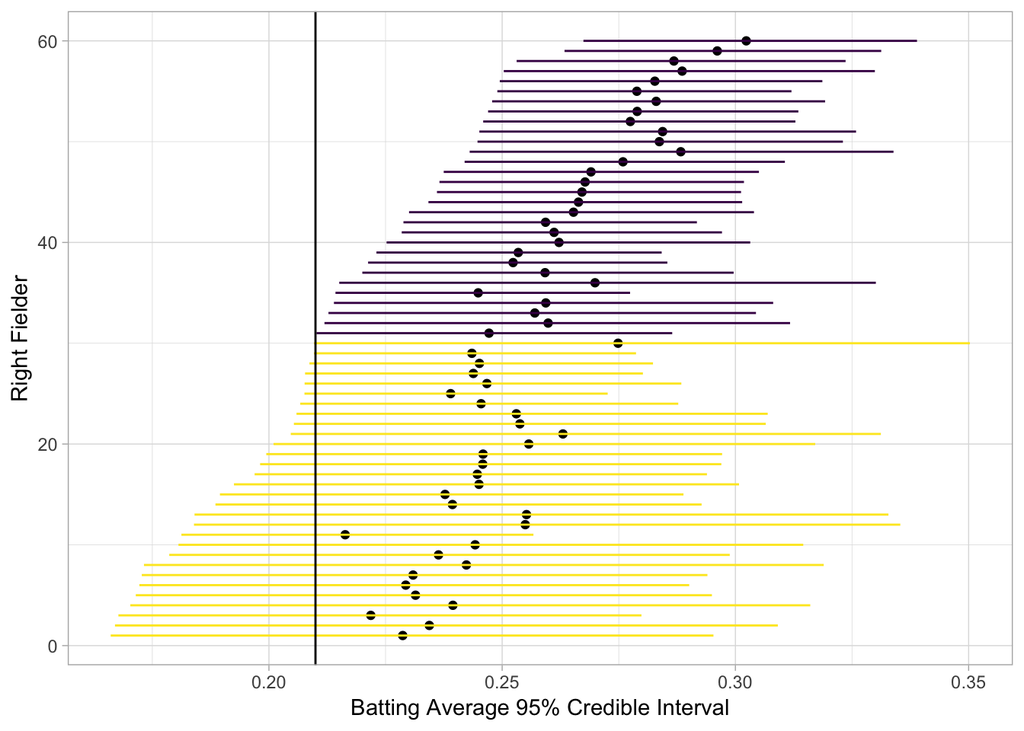

#### Question 3

Let’s consider 2nd baseman Thomas Field and 1st baseman Prince Fielder. In 2012, Thomas Field only had 2 at bats with 0 hits, while Fielder was able to get 182 hits off of 581 at bats. This is summarized in the following table.

| Player | PriPos | Hits | AtBats | PlayerNumber | PriPosNumber |
| --- | --- | --- | --- | --- | --- |
| Thomas Field | 2nd Base | 0 | 2 | 266 | 4 |
| Prince Fielder | 1st Base | 182 | 581 | 267 | 3 |

Clearly we have much more data on Fielder than Field, so we would expect to have less certainty in our posterior estimates. This is precisely what we see in the plots below. On the top row we have the posterior samples for both players. Note that our model has predicted Thomas Field to have the lower batting average of the two, which makes sense given the data.

The bottom row gives the posterior medians (points) and the 80% and 95% credible regions (thick and thin segments, respectively) for both players. This way the posterior samples are compared on a common scale. It is easy to see Field’s posterior distribution is significantly wider than that of Fielder’s. To be precise, the 95% credible region for Field and Fielder are (0.165, 0.328) and (0.27, 0.338), respectively. The median posterior estimates for Field and Fielder’s batting averages are 0.243 and 0.303, respectively.

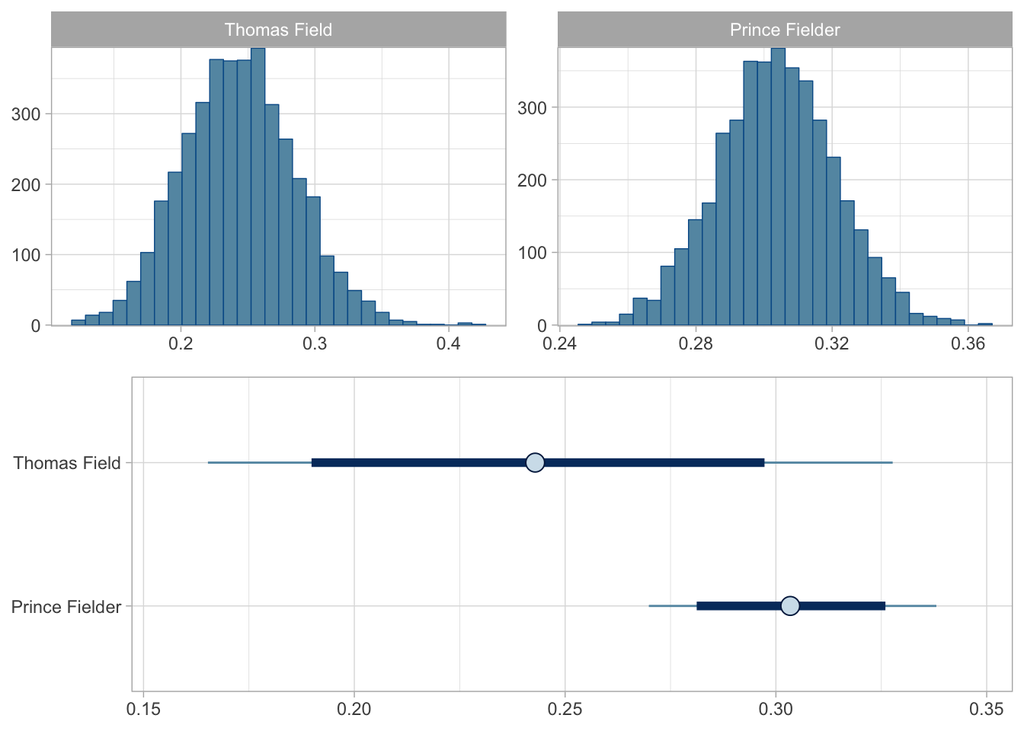